# 10. Adolescencia y salud mental

## ¿Qué es la salud mental?

Es el equilibrio entre pensamientos, emociones y conductas que nos permite vivir y relacionarnos de forma saludable.

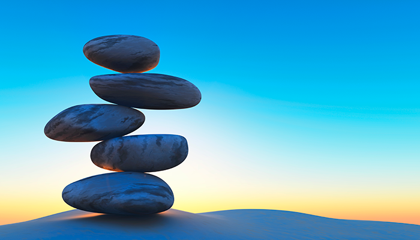

“Equilibrio” es la palabra clave en salud mental. Fuente: soybibliotecario.blogspot.com

La adolescencia es una etapa de grandes cambios físicos, emocionales y sociales. Es un momento de búsqueda de identidad, de pertenencia al grupo, de mayor independencia y, al mismo tiempo, de necesidad de contención. La salud mental en esta etapa es tan importante como la salud física.

## Temas centrales (primera parte)

Hay varios temas importantes en salud mental. Aquí veremos algunos que se pueden trabajar en grupos (jigsaw):

- Texto 1: Estrés
- Texto 2: Depresión
- Texto 3: Violencia
- Texto 4: Tiempo libre

## Actividad 2

El ______ es la respuesta del cuerpo y la mente ante situaciones que percibimos como desafiantes o amenazantes. Puede ser ______ (cuando nos motiva) o ______ (cuando nos supera). La ______ no es “estar triste” solamente. Es un trastorno que afecta pensamientos, emociones y conductas. Los ______ son: tristeza persistente, pérdida de interés, cambios en el sueño y apetito, sentimientos de inutilidad. Requiere atención y acompañamiento. El ______ libre es necesario para descansar, disfrutar y expresarse. Hay que usarlo bien sabiendo que actividades creativas, deportivas y solidarias ayudan a la salud mental. La ______ puede ser ______, verbal, psicológica. Genera inseguridad, miedo y afecta el bienestar. Es importante reconocerla y buscar ayuda.

## Temas centrales (parte 2)

Otros temas centrales relacionados con la salud mental son:

- **a)** El gran tema de aceptarse a sí mismo.
- **b)** El apoyo que es para cualquier problema la familia en primer lugar, y luego los amigos y la escuela.
- **c)** Los factores de riesgo que hay que evitar: consumo de sustancias, aislamiento, violencia familiar, presión social.
- **d)** Prevención de pensamientos de hacerse daño a sí mismo, al cuerpo, a la propia vida. Pueden aparecer especialmente en situaciones de depresión, angustia intensa o problemas emocionales. Aquí reconocer los indicios es clave: cambios bruscos de conducta, aislamiento, tristeza prolongada o expresiones de desesperanza. Frente a estas señales, pedir ayuda a adultos de confianza o profesionales de la salud es fundamental y puede marcar la diferencia.

## Actividad 3

Desarrolla en unos 10 renglones algún factor de riesgo que tu elijas. Debe contener, cualquier sea el tema, estas palabras o frases: “salud mental”, “factor”, “aislarse”, “equilibrio”. “emocional”.

## Actividad 4

Algo que da paz y salud (también mental) es la aceptación de sí mismo. Consiste en aceptar lo que nos ha tocado en la vida, aquellas limitaciones que no elegimos pero también ver y valorar las cosas buenas que tenemos. Aceptarse a sí mismo no significa decir “yo soy asi” y no hacer nada por mejorar. Significa dar lo mejor de nosotros y superarnos pero sin ansiedad mala o enfermisa.

Mira ese [cortometraje](https://www.youtube.com/watch?v=CkdI1F5xxtE) que muestra cómo el reconocimiento, la aceptación y el acompañamiento pueden transformar la vida de una persona.

Para aprobar esta guía deberás reflexionar sobre este video ayudado por las preguntas de abajo y exponerlo oralmente al profesor. Si quieres puedes escribir las respuestas para acordarte y repasarlo pero lo decisivo es la conversación.

**Preguntas para la reflexión:**

1. ¿Qué sentimientos te despertó la historia?
2. ¿Qué rol cumplen los demás en el proceso de aceptación de uno mismo?
3. ¿Por qué es importante que alguien crea en nosotros?
4. ¿Qué relación encontrás entre la historia y los temas de salud mental en la adolescencia?

**“Entregar como tarea de alternancia todas las actividades, incluida la 4”**

## Actividad 5: Análisis de un caso

(Desarrollada en el aula)

Tomás tiene 16 años y está en 4º año de la secundaria. Siempre fue buen estudiante, pero este año nota que le cuesta más concentrarse.

Su rutina normal es:

- **Mañana**: se levanta a las 6:30 para ir a la escuela. A veces desayuna, a veces no porque prefiere dormir “cinco minutos más”.
- **Tarde**: tres veces por semana entrena en el club de fútbol hasta las 20:30. Los otros días se junta con amigos o hace tareas.
- **Noche**: cena con su familia, pero después suele quedarse en la compu o el celular. A veces estudia tarde, otras juega en línea o se queda en redes sociales. Se acuesta alrededor de la 1:30–2:00 a.m.
- **Fines de semana**: duerme hasta el mediodía. Si juega al fútbol temprano, le cuesta rendir.

Últimamente:

- Llega muy cansado a la escuela y se queda dormido en clase.
- Sus entrenadores le dicen que bajó el rendimiento.
- Está más irritable con sus amigos y familia.
- Para no dormirse cuando estudia, toma bebidas energizantes.
- Siente que “no tiene tiempo para nada” y se frustra.

**Contestar:**

1. **Detectar hábitos**:
   - ¿Qué cosas hace Tomás que perjudican su sueño?
   - ¿Qué otras responsabilidades/actividades le generan presión de tiempo?
2. **Consecuencias**:
   - ¿Qué problemas ya está teniendo?
   - ¿Qué consecuencias a largo plazo podría sufrir si no cambia nada?
3. **Perspectivas múltiples**:
   - Si fueras su entrenador, ¿qué le recomendarías?
   - Si fueras su mejor amigo, ¿qué consejo le darías?
   - Si fueras su profesor, ¿cómo podrías ayudarlo?
   - Si fueras Tomás, ¿qué priorizarías: dormir más, entrenar, salir con amigos, estudiar…? ¿Por qué?
4. **Propuestas**:
   - Diseñen **al menos 3 alternativas posibles** para mejorar la situación de Tomás.
   - Analicen pros y contras de cada alternativa.